# Santander Product recommendation

Rushi Chaudari & Jayachandra Chimakurthi

10/13/2020

Importing the required packages in the work environment.

```r
library(data.table)
library(dplyr)
library(tidyr)
library(lubridate)
library(ggplot2)
library(stringr)
library(arules)
library(rattle)
library(mlr)
library(randomForestSRC)
library(rFerns)
library(neuralnet)
```

Setting the theme.

```r
my_theme <- theme_bw() +
theme(axis.title=element_text(size=14),
plot.title=element_text(size=20),
axis.text =element_text(size=8))

my_theme_dark <- theme_dark() +
theme(axis.title=element_text(size=24),
plot.title=element_text(size=36),
axis.text =element_text(size=16))
```

Background and Introduction:

Santander Bank, formerly known as Sovereign Bank, is a subdivision of the Spanish Santander Group. The retail banking company is one of the largest commercial banks in the United States of America, with over 600 branches, 2000 ATMs, 9900 employees, and 2 million customers. It provides a wide range of products like credit cards, insurance, loans, debit cards, electronic banking etc. It used to (before the release of the dataset) give a wide range of product recommendations only to some of its customers. In contrast, other customers rarely got any. From the scope of the offers, only a few of them were more likely to be used by the customer, which resulted in uneven customer experience.

Problem Statement:

The objective of the project was to analyze 18 months of Santander Spain’s customer behaviour data and predict what new products does the customer buys in June 2016 based on their past behaviour. With the predicted data, Santander can promote their products to all the customers and can even target promotions to do better business and ensure customer gratification.

2. Data Exploration and Visualization

Data Description: The data is extracted from the Kaggle data science competition challenge(Santander product recommendation). The data set contains artificial Santander Spain’s anonymized customer data of 929615 test users across 24 predictors, namely between January 2015 and May 2016. All the possible products are named by the format ind_(xyz)_ult1.

Importing the training dataset and test dataset from Kaggle.

```r
data <- read.csv("train_50k.csv")
data <- data[, -c(1)]
test_data <- read.csv("/home/doraemon/test_ver2.csv")
data <- data[-c(1)]
test_data <- test_data[-c(1)]
```

Data Cleaning:

We performed several steps to clean and prepare the data for further analysis such as missing value treatments,splitting, data consolidation, character value sanitization etc.

1. Converting the Date Variable to its correct format

Transformed the dates stored in character and numeric vectors to POSIXct objects.

```r
data$fecha_alta <- ymd(data$fecha_alta)
test_data$fecha_alta <- ymd(test_data$fecha_alta)
```

2. Handling Missing Data (Imputation, likewise detection, feature elmination)

Likewise Detection:-

We have applied likewise detection for handling missing values as the missing data is limited to a small number of observations.

```r
prod_cols <- colnames(data[str_detect( colnames(data),"_ult1")])
all_cols <- colnames(data)
user_cols <- colnames(data[ ! all_cols %in% prod_cols])
data_missing_columns <- names(data)[which(sapply(data, function(x) any(is.na(x))))]
missing_data <- sapply(data[,data_missing_columns], function(x) sum(is.na(x)))
missing_data_pct <- sapply(data[,data_missing_columns], function(x) round(sum(is.na(x))/dim(data)[1],5))
complete_cases_pct <- dim(data[complete.cases(data[user_cols]),])[1]/dim(data[user_cols])[1]*100
```

3. Feature Elimination

Few other columns were removed which doesn’t impact the customer purchase behaviour such as indrel_1mes -> Customer type at the beginning of the month, indext -> foreigner index and indfall -> deceased index.

```r
data <- data[, !(colnames(data) %in% c("conyuemp","ult_fec_cli_1t"))]
data <- data[, !(colnames(data) %in% c("tipodom","cod_prov"))]
data <- data[,!names(data) %in% c("indrel_1mes","indext","indfall")]

test_data <- test_data[, !(colnames(test_data) %in% c("conyuemp","ult_fec_cli_1t"))]
test_data <- test_data[, !(colnames(test_data) %in% c("tipodom","cod_prov"))]
test_data <- test_data[,!names(test_data) %in% c("indrel_1mes","indext","indfall")]

data$year_alta <- year(data$fecha_alta)
data$month_alta <- month(data$fecha_alta,label=T)
test_data$year_alta <- year(test_data$fecha_alta)
test_data$month_alta <- month(test_data$fecha_alta,label=T)
```

4. Missing Value Imputation

We have applied mode imputation for the categorical variable “tiprel_1mes” -> Customer relation type at the beginning of the month and assigned value of “A” since it is the majority status and the columns sex0-> sex, canal_entrada -> channel of entry, nomprov -> province name, we created a new level “unknown” and assigned to it.

```r
data$nomprov <- as.character(data$nomprov)
data$nomprov[is.na(data$nomprov)] <- "UNKNOWN"
data$canal_entrada <- as.character(data$canal_entrada)
data$canal_entrada[is.na(data$canal_entrada)] <- "UNKNOWN"
data$sexo <- as.character(data$sexo)
data$sexo[is.na(data$sexo)] <- "UNKNOWN"
data$ind_nomina_ult1[is.na(data$ind_nomina_ult1)] <- 0
data$ind_nom_pens_ult1[is.na(data$ind_nom_pens_ult1)] <- 0
data$tiprel_1mes <- as.character(data$tiprel_1mes)

data$tiprel_1mes[is.na(data$tiprel_1mes)] <- "A"
data$segmento <- as.character(data$segmento)
data$segmento[is.na(data$segmento)] <- "UNKNOWN"

test_data$nomprov <- as.character(test_data$nomprov)
test_data$nomprov[is.na(test_data$nomprov)] <- "UNKNOWN"
test_data$canal_entrada <- as.character(test_data$canal_entrada)
test_data$canal_entrada[is.na(test_data$canal_entrada)] <- "UNKNOWN"
test_data$sexo <- as.character(test_data$sexo)
test_data$sexo[is.na(test_data$sexo)] <- "UNKNOWN"
test_data$tiprel_1mes <- as.character(test_data$tiprel_1mes)
test_data$tiprel_1mes[is.na(test_data$tiprel_1mes)] <- "A"
test_data$segmento <- as.character(test_data$segmento)
test_data$segmento[is.na(test_data$segmento)] <- "UNKNOWN"

all_cols <- colnames(data)
user_cols <- colnames(data[ ! all_cols %in% prod_cols])
data$tiprel_1mes <- as.factor(data$tiprel_1mes)
data$sexo <- as.factor(data$sexo)
data$canal_entrada <- as.factor(data$canal_entrada)
data$segmento <- as.factor(data$segmento)
data$nomprov <- as.factor(data$nomprov)

all_cols <- colnames(test_data)
user_cols <- colnames(test_data[ ! all_cols %in% prod_cols])
test_data$tiprel_1mes <- as.factor(test_data$tiprel_1mes)
test_data$sexo <- as.factor(test_data$sexo)
test_data$canal_entrada <- as.factor(test_data$canal_entrada)
test_data$segmento <- as.factor(test_data$segmento)
test_data$nomprov <- as.factor(test_data$nomprov)
```

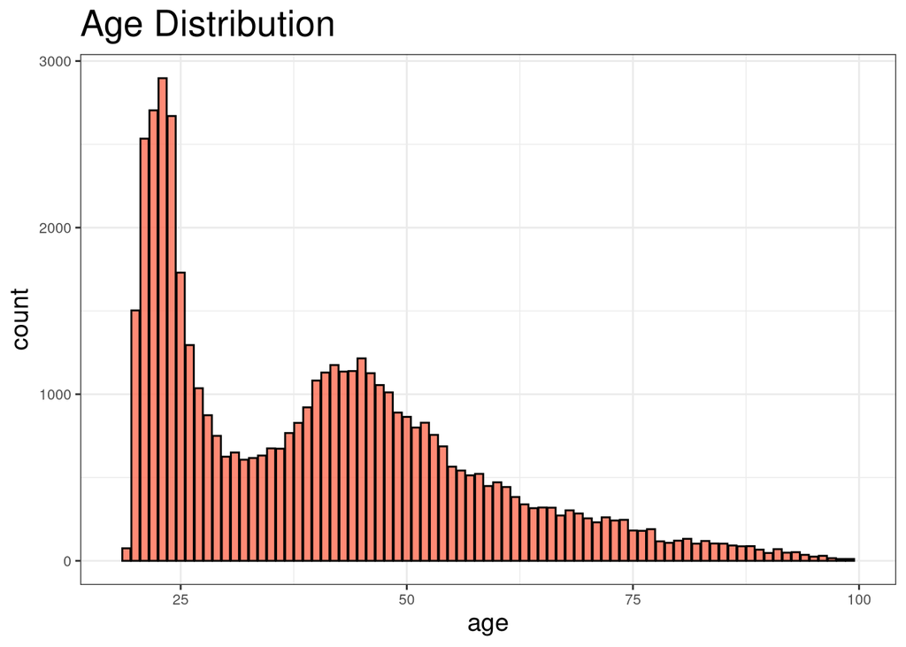

```r
ggplot(data=data,aes(x=age)) +
  geom_bar(alpha=0.75,fill="tomato",color="black") +
  xlim(c(18,100)) +
  ggtitle("Age Distribution") +
  my_theme
```

```r
data$age[(data$age < 18)] <- median(data$age[(data$age >= 18) & (data$age <=30)])
data$age[(data$age > 100)] <- median(data$age[(data$age >= 30) & (data$age <=100)])

test_data$age[(test_data$age < 18)] <- median(test_data$age[(test_data$age >= 18) & (test_data$age <=30)])
test_data$age[(test_data$age > 100)] <- median(test_data$age[(test_data$age >= 30) & (test_data$age <=100)])
```

The column “renta” (income) is imputed by median income of the city where the customer belongs as the income data is skewed.

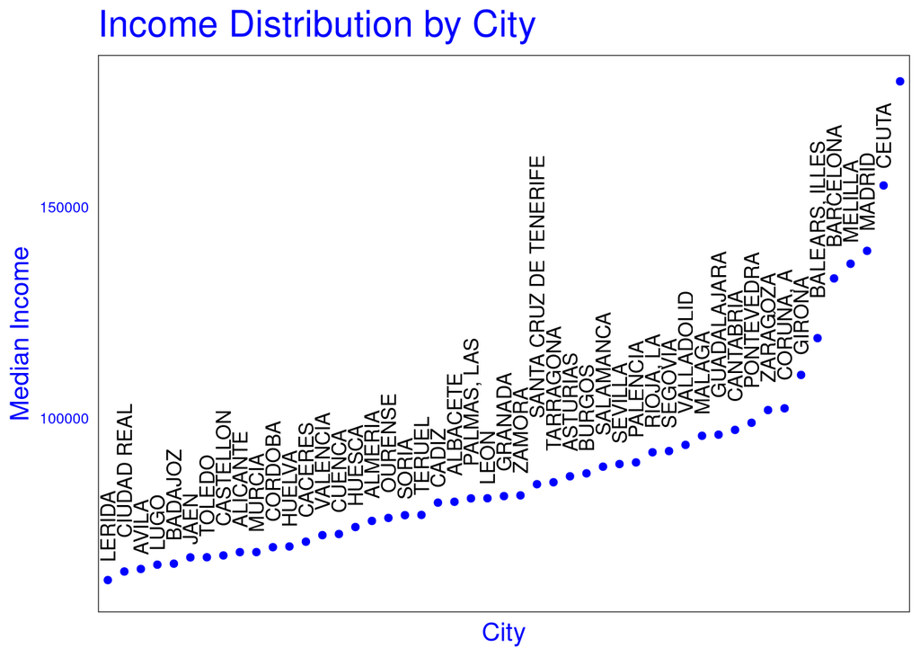

```r
data %>%
  filter(!is.na(renta)) %>%
  group_by(nomprov) %>%
  summarise(med.income = median(renta)) %>%
  arrange(med.income) %>%
  mutate(city=factor(nomprov,levels=nomprov)) %>%
  ggplot(aes(x=city,y=med.income)) +
  geom_point(color="blue") +
  guides(color=FALSE) +
  xlab("City") +
  ylab("Median Income") +
  my_theme +
  theme(axis.text.x=element_blank(), axis.ticks = element_blank()) +
  geom_text(aes(x=city,y=med.income,label=city),angle=90,hjust=-.25) +
  theme(plot.background=element_rect(),
        panel.grid =element_blank(),
        axis.title =element_text(color="blue"),
        axis.text  =element_text(color="blue"),
        plot.title =element_text(color="blue")) +
  ylim(c(60000,180000)) +
  ggtitle("Income Distribution by City")
```

```r
new.incomes <-data %>% select(nomprov) %>%
                       merge(data %>% group_by(nomprov) %>%
                            summarise(med.income=median(renta,na.rm=TRUE)),by="nomprov") %>%
                       select(nomprov,med.income) %>%
                       arrange(nomprov)
data <- arrange(data,nomprov)
data$renta[is.na(data$renta)] <- new.incomes$med.income[is.na(data$renta)]

data$renta[is.na(data$renta)] <- median(data$renta,na.rm=TRUE)


test_data$renta <- as.numeric(test_data$renta)

new.incomes <-test_data %>% select(nomprov) %>%
                       merge(test_data %>% group_by(nomprov) %>%
                            summarise(med.income=median(renta,na.rm=TRUE)),by="nomprov") %>%
                       select(nomprov,med.income) %>%
                       arrange(nomprov)
test_data <- arrange(test_data,nomprov)
test_data$renta[is.na(test_data$renta)] <- new.incomes$med.income[is.na(test_data$renta)]

test_data$renta[is.na(test_data$renta)] <- median(test_data$renta,na.rm=TRUE)
```

```r
char.cols <- names(data)[sapply(data,is.character)]
for (name in char.cols){
  print(sprintf("Unique values for %s:", name))
  print(unique(data[[name]]))
  cat('\n')
}
```

```
[1] "Unique values for ind_empleado:"
[1] "N" "F" "A" "B" NA

[1] "Unique values for pais_residencia:"
 [1] "ES" "CN" "AR" NA   "BE" "BR" "MX" "JP" "US" "BO" "GB" "CL" "NL" "FR" "CH"
[16] "CO" "IT" "RU" "DE" "BG" "DO" "NZ" "SE" "VE" "RO" "PL" "EC" "PA" "IL" "PY"
[31] "PE" "TN" "CA" "PT" "GQ" "FI" "UY" "AE" "LT" "MR" "CM" "AD" "IN" "AO" "KE"
[46] "GE" "GR" "GW" "HR" "SV" "SA" "MD" "UA" "EG" "HN" "DJ" "MA" "DK" "SG" "IE"
[61] "NO"

[1] "Unique values for antiguedad:"
  [1] "      5" "     29" "    156" "    130" "     12" "    149" "     16"
  [8] "     24" "    151" "     14" "    190" "    195" "     39" "     53"
 [15] "     95" "     36" "      0" "     31" "     20" "    155" "    199"
 [22] "     71" "    137" "    129" "     97" "     17" "     84" "     13"
```

[output cut: 36 more lines]

```r
char.cols <- names(test_data)[sapply(test_data,is.character)]
for (name in char.cols){
  print(sprintf("Unique values for %s:", name))
  print(unique(test_data[[name]]))
  cat('\n')
  }
```

```
[1] "Unique values for ind_empleado:"
[1] "N" "B" "A" "F" "S"

[1] "Unique values for pais_residencia:"
  [1] "CH" "DE" "GB" "BE" "DJ" "IE" "QA" "US" "VE" "DO" "SE" "AR" "CA" "PL" "CN"
 [16] "CM" "FR" "AT" "RO" "LU" "PT" "CL" "IT" "MR" "MX" "SN" "BR" "CO" "PE" "RU"
 [31] "LT" "EE" "MA" "HN" "BG" "NO" "GT" "UA" "NL" "GA" "IL" "JP" "EC" "IN" "DZ"
 [46] "ET" "SA" "HU" "JM" "CI" "CU" "BO" "TG" "TN" "NG" "AU" "GR" "DK" "LB" "UY"
 [61] "TH" "SG" "MD" "SK" "AD" "BY" "HK" "HR" "EG" "GQ" "PR" "ZA" "PA" "KE" "TR"
 [76] "FI" "BA" "SV" "ES" "PY" "PK" "KR" "AO" "GN" "IS" "TW" "MK" "VN" "CZ" "CR"
 [91] "MZ" "MT" "LY" "GH" "KH" "AE" "RS" "OM" "GE" "NI" "GI" "NZ" "MM" "PH" "KW"
[106] "BM" "CG" "ML" "AL" "ZW" "CF" "GM" "CD" "BZ" "KZ" "GW" "SL" "LV"

[1] "Unique values for indresi:"
[1] "N" "S"
```

```r
data[,prod_cols] <- lapply(data[,prod_cols],function(x)as.integer(round(x)))
```

We had imputed the minor class to “Other” for few categorical columns such as “nomprov” (province name), “pais_residencia” (country of residence) and “canal_entrada” (channel of entry).

```r
unique_countries <- length(unique(data$pais_residencia))
top_10_countries <- data %>%
  group_by(pais_residencia) %>%
  summarise(count_by_countries=n())  %>%
  select(pais_residencia,count_by_countries) %>% arrange(-count_by_countries) %>% head(10)
#kable(top_10_countries)
data$pais_residencia <- as.character(data$pais_residencia)
data$countries <- ifelse(data$pais_residencia %in% c('ES'), data$pais_residencia,'Other')

unique_countries <- length(unique(test_data$pais_residencia))
top_10_countries <- test_data %>%
  group_by(pais_residencia) %>%
  summarise(count_by_countries=n())  %>%
  select(pais_residencia,count_by_countries) %>% arrange(-count_by_countries) %>% head(10)
test_data$pais_residencia <- as.character(test_data$pais_residencia)



unique_channels <- length(unique(data$canal_entrada))
top_10_channels <- data %>%
  group_by(canal_entrada) %>%
  summarise(count_by_channels=n())  %>%
  select(canal_entrada,count_by_channels) %>% arrange(-count_by_channels) %>% head(10)
#kable(top_10_channels)
data$canal_entrada <- as.character(data$canal_entrada)
data$channel <- ifelse(data$canal_entrada %in% c('KHE', 'KAT', 'KFC','UNKNOWN'), data$canal_entrada,'Other')

unique_channels <- length(unique(test_data$canal_entrada))
top_10_channels <- test_data %>%
  group_by(canal_entrada) %>%
  summarise(count_by_channels=n())  %>%
  select(canal_entrada,count_by_channels) %>% arrange(-count_by_channels) %>% head(10)
test_data$canal_entrada <- as.character(test_data$canal_entrada)
test_data$channel <- ifelse(test_data$canal_entrada %in% c('KHE', 'KAT', 'KFC','UNKNOWN'), test_data$canal_entrada,'Other')

unique_provinces <- length(unique(data$nomprov))
top_10_provinces <- data %>%
  group_by(nomprov) %>%
  summarise(count_by_provinces=n())  %>%
  select(nomprov,count_by_provinces) %>% arrange(-count_by_provinces) %>% head(10)
#kable(top_10_provinces)
data$nomprov <- as.character(data$nomprov)
data$provinces <- ifelse(data$nomprov %in% c('MADRID', 'BARCELONA', 'VALENCIA'), data$nomprov,'Other')

unique_provinces <- length(unique(test_data$nomprov))
top_10_provinces <- test_data %>%
  group_by(nomprov) %>%
  summarise(count_by_provinces=n())  %>%
  select(nomprov,count_by_provinces) %>% arrange(-count_by_provinces) %>% head(10)
test_data$nomprov <- as.character(test_data$nomprov)
test_data$provinces <- ifelse(test_data$nomprov %in% c('MADRID', 'BARCELONA', 'VALENCIA'), test_data$nomprov,'Other')
```

Exploratory Data Analysis:

We had performed exploratory data analysis to analyze the data and summarize the main characteristics.

1. Analysis of Customer Initiation into the Bank by Month:-

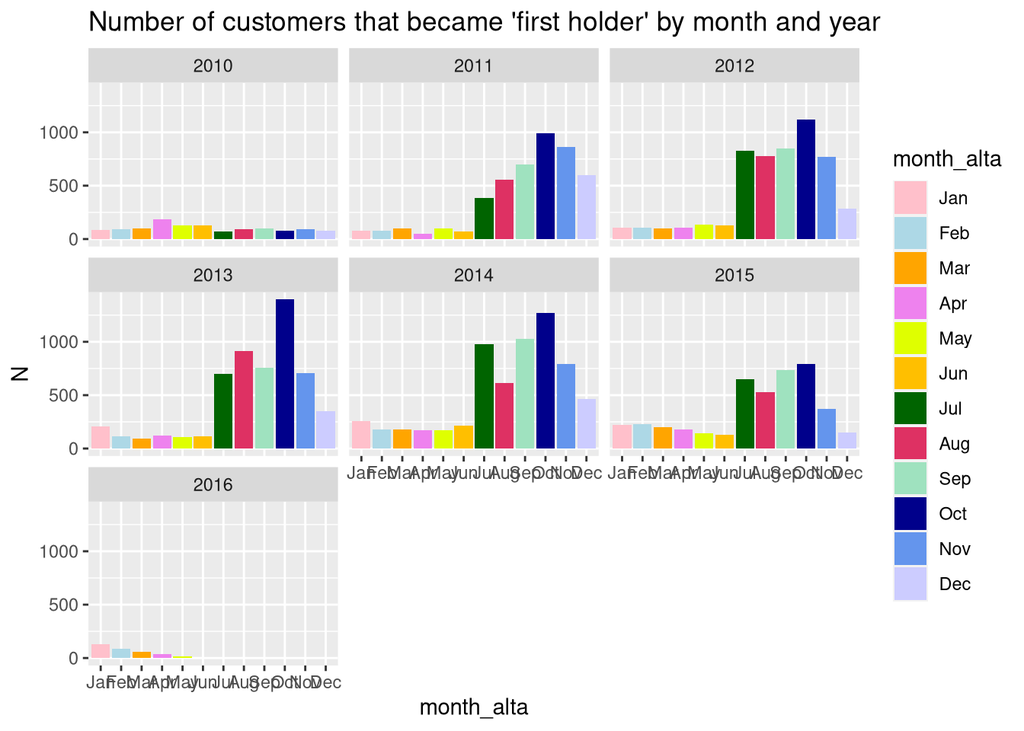

```r
data <- as.data.table(data)
ggplot(data[year_alta>2009,.N, by =.(month_alta,year_alta)],aes(x = month_alta,y=N,fill=month_alta,))+
  geom_bar(stat="identity")+ggtitle("Number of customers that became 'first holder' by month and year")+
  facet_wrap(~year_alta) +scale_fill_manual(values=c("pink", "light blue","orange","violet","#DFFF00","#FFBF00","dark green","#DE3163","#9FE2BF","dark blue","#6495ED","#CCCCFF"))
```

There is a significant rise in the number of new bank accounts in the month of July and that remains till october.

2. Analysis of Customer Age and Segmentation

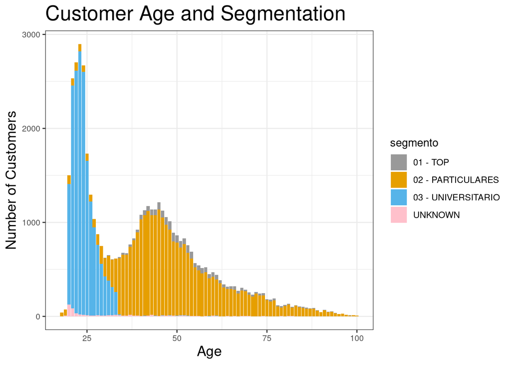

   ```r
   age_segmento <- ggplot(data, aes(x=age)) +
     geom_bar(
   aes(fill=segmento )
     ) +
     labs(title="Customer Age and Segmentation") +
     labs(x="Age", y="Number of Customers") +
     scale_fill_discrete(name = "Segmentation",
                     labels = c("VIP", "Individuals","College Graduated","Unnoted"))+
     my_theme + scale_fill_manual(values=c("#999999", "#E69F00", "#56B4E9","#FFC0CB"))
   age_segmento
   ```

   We can observe from the plot, college graduate are the young people with majority of the student fall in the age between 20-26 years and VIP and Individuals are middle aged.
3. Analysis on Channel of Entry and Household Income

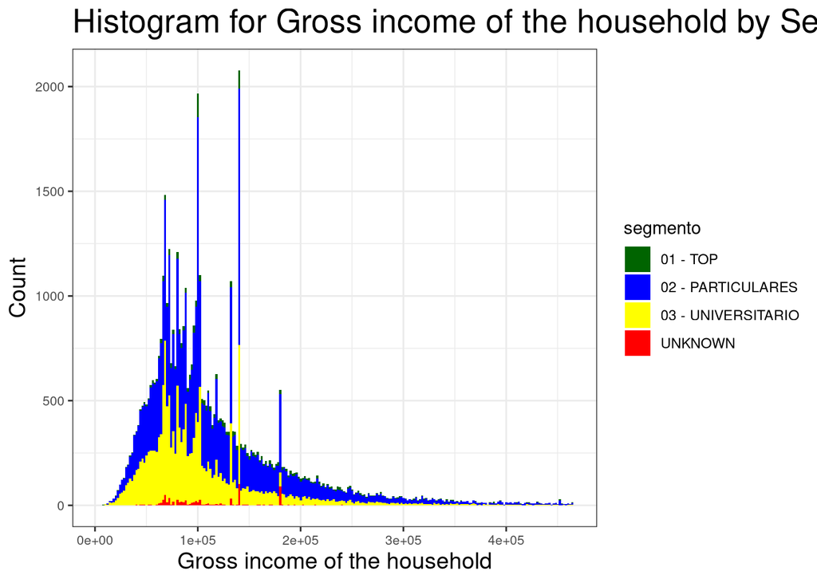

```r
income_segment <- ggplot(data, aes(renta)) +
  geom_histogram(breaks=seq(1203, 155500*3, by = 2000),
                 aes(fill=segmento)) +
  labs(title="Histogram for Gross income of the household by Segment") +
  labs(x="Gross income of the household", y="Count")  +
  my_theme + scale_fill_manual(values=c("dark green", "blue", "yellow","red"))
income_segment
```

We can observe from the plot VIP customers had the highest income and the graduate students has low income compared to household gross incomes

4.Analysis on Customer Age and Channel.

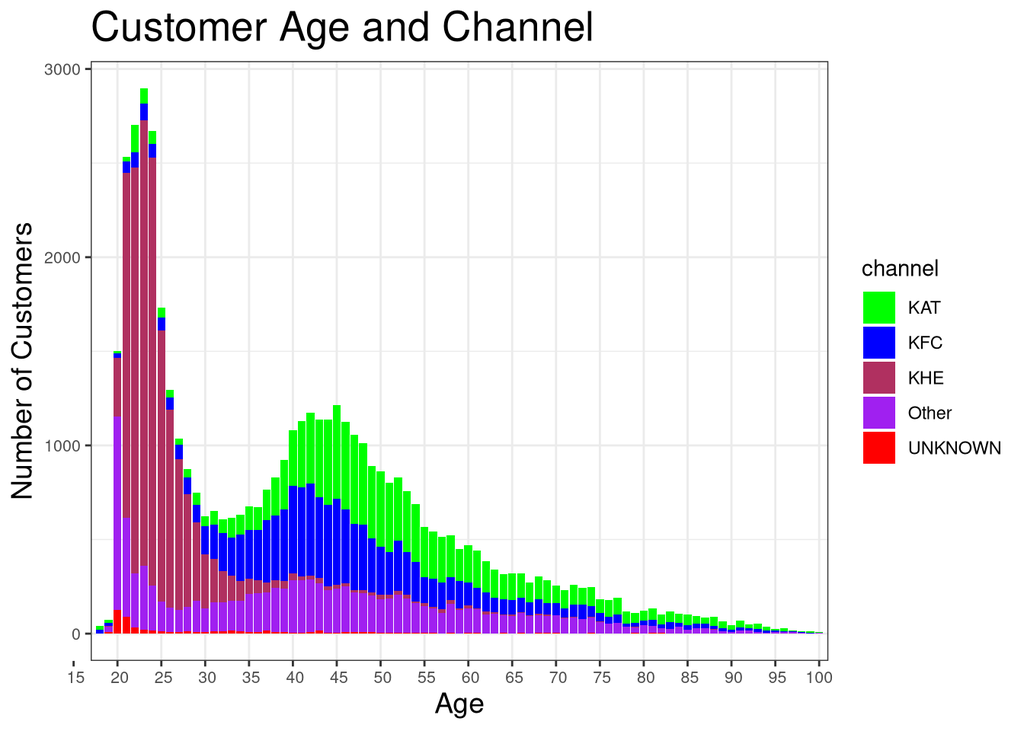

```r
age_channel <- ggplot(data, aes(x=age))+  geom_bar(aes(fill=channel))+ xlab("Age") + ylab("Number of Customers")+ ggtitle("Customer Age and Channel") + my_theme + scale_x_discrete(limit = c(0,15,20,25,30,35,40,45,50,55,60,65,70,75,80,85,90,95,100))
age_channel + scale_fill_manual(values=c(" green", "blue", "maroon","purple","red"))
```

We can observe the students(18- 26 years) use “KHE” as the channel of entry.

5. Analysis on Gross Income and channel.

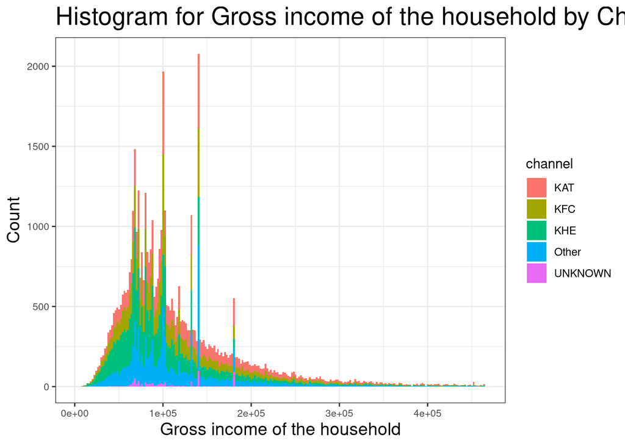

```r
income_channel <- ggplot(data, aes(renta)) + geom_histogram(breaks=seq(1203, 155500*3, by = 2000),
                 #col="red",
                 aes(fill=channel)) +
  labs(title="Histogram for Gross income of the household by Channel") +
  labs(x="Gross income of the household", y="Count") +
  my_theme
income_channel
```

6. Analysis of the Popularity of Products

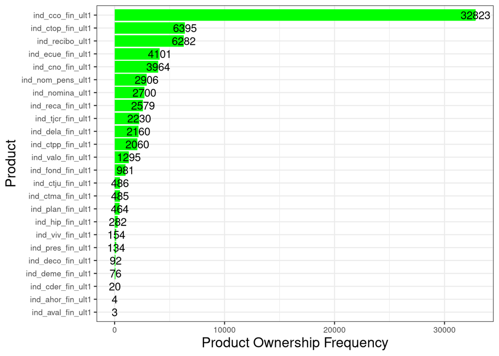

```r
product_popularity_plot <- data %>% select(ind_ahor_fin_ult1:ind_recibo_ult1) %>% summarise_each(funs(sum)) %>% gather(product, frequency, ind_ahor_fin_ult1:ind_recibo_ult1) %>% ggplot(aes(x = reorder(product,frequency), y = frequency)) + geom_bar(stat="identity", position="dodge", fill="green") + labs(y = "Product Ownership Frequency", x = "Product") + my_theme + geom_text(aes(label = frequency), position=position_dodge(width=1.5))+ coord_flip()
product_popularity_plot
```

We can observe from the bar chart that the “ind_cco_fin_ult1”( current accounts) has the highest customer ownernship and followed by the products “ind_ctop_fin_ult1” (Particular Account) and “ind_recibo_ult1” (Direct Debit).

7. Analysis on Product Popularity by Segments

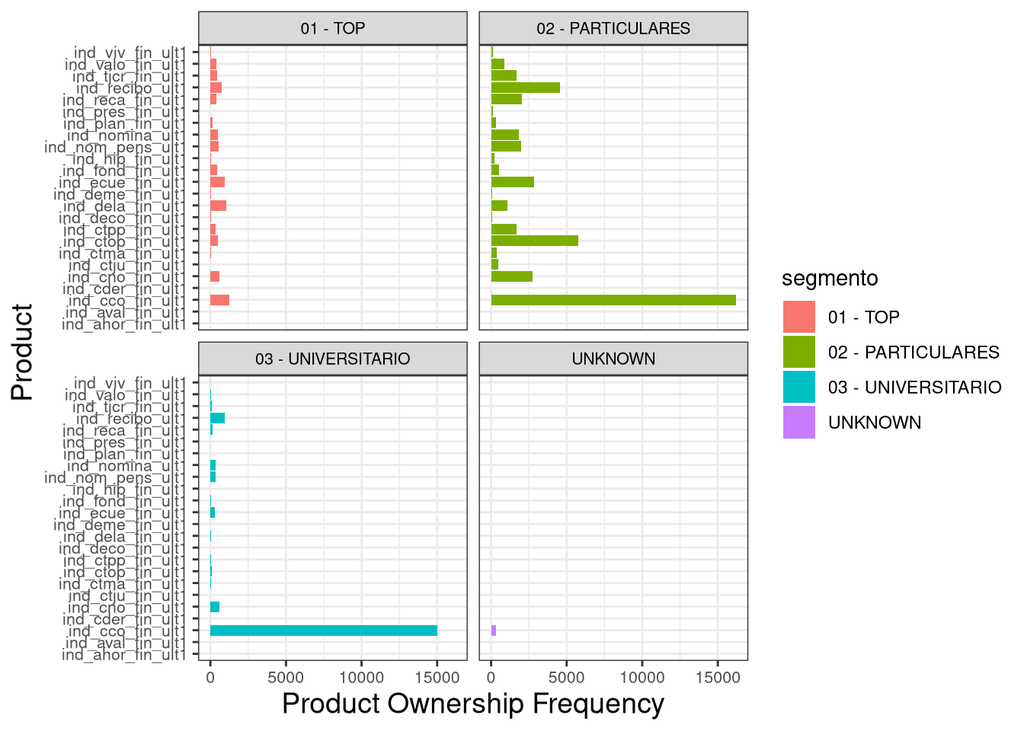

```r
product_popularity_per_segment <- data %>% group_by(segmento) %>% select(segmento:ind_recibo_ult1) %>% summarise_each(funs(sum)) %>% gather(product, frequency, ind_ahor_fin_ult1:ind_recibo_ult1) %>%  ggplot(aes(x = product, y = frequency)) + geom_bar(stat="identity", position="dodge", aes(fill=segmento)) + labs(y = "Product Ownership Frequency", x = "Product") + my_theme + facet_wrap(~segmento) + theme(strip.text.x = element_text(size = 8, colour = "black")) + coord_flip()
product_popularity_per_segment
```

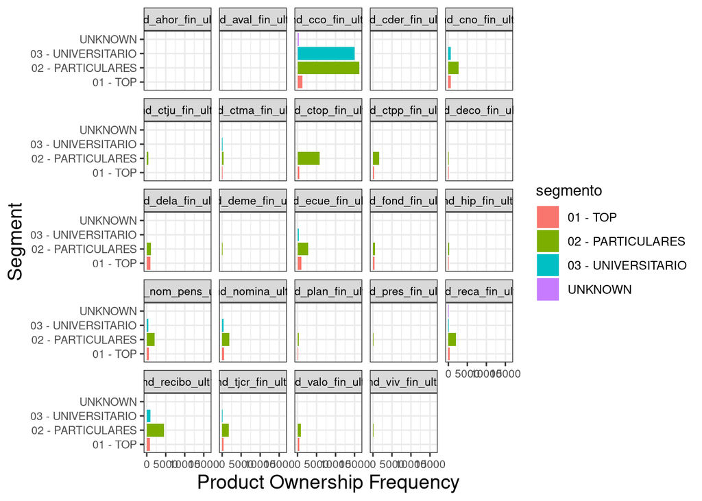

```r
segments_per_product <- data %>% group_by(segmento) %>% select(segmento:ind_recibo_ult1) %>% summarise_each(funs(sum)) %>% gather(product, frequency, ind_ahor_fin_ult1:ind_recibo_ult1) %>%  ggplot(aes(x = segmento, y = frequency)) + geom_bar(stat="identity", position="dodge", aes(fill=segmento)) + labs(y = "Product Ownership Frequency", x = "Segment") + my_theme + facet_wrap(~product) + theme(strip.text.x = element_text(size = 8, colour = "black")) + coord_flip()
segments_per_product
```

We can observe that current accounts products is the most popular when compared to the other products with university students and the particular groups where the gross income is less than the average household income.

8. Analysis on Product popularity by Sex

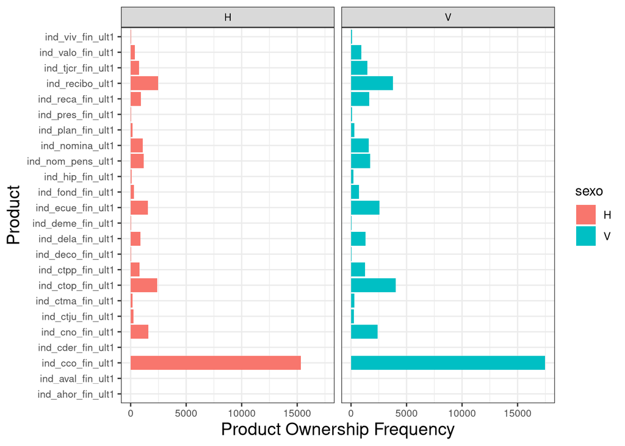

```r
product_popularity_per_sex <- data[sexo!="UNKNOWN",] %>% group_by(sexo) %>% select(sexo, ind_ahor_fin_ult1:ind_recibo_ult1) %>% summarise_each(funs(sum)) %>% gather(product, frequency, ind_ahor_fin_ult1:ind_recibo_ult1) %>%  ggplot(aes(x = product, y = frequency)) + geom_bar(stat="identity", position="dodge", aes(fill=sexo)) + labs(y = "Product Ownership Frequency", x = "Product") + my_theme + facet_wrap(~sexo) + theme(strip.text.x = element_text(size = 8, colour = "black")) + coord_flip()
product_popularity_per_sex
```

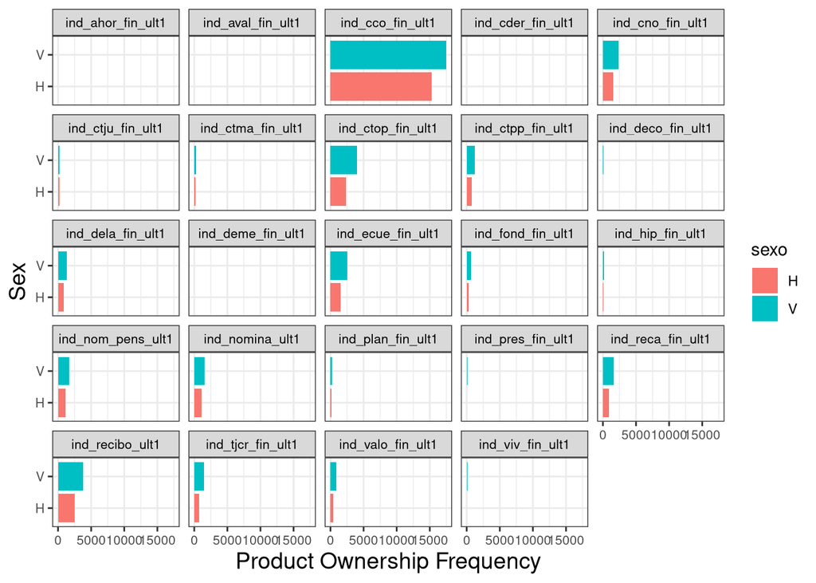

```r
sex_per_product <- data[sexo!="UNKNOWN",] %>% group_by(sexo) %>% select(sexo, ind_ahor_fin_ult1:ind_recibo_ult1) %>% summarise_each(funs(sum)) %>% gather(product, frequency, ind_ahor_fin_ult1:ind_recibo_ult1) %>%  ggplot(aes(x = sexo, y = frequency)) + geom_bar(stat="identity", position="dodge", aes(fill=sexo)) + labs(y = "Product Ownership Frequency", x = "Sex") + my_theme + facet_wrap(~product) + theme(strip.text.x = element_text(size = 8, colour = "black")) + coord_flip()
sex_per_product
```

Males are higher proportion than females in the data and there is no much difference between the products owned by females and males.

Association Rule Mining and Market Basket Analysis of Products:-

```r
mb_data <- data %>% select(ncodpers,ind_ahor_fin_ult1:ind_recibo_ult1) %>% gather(product,ownership,ind_ahor_fin_ult1:ind_recibo_ult1)
mb_data <- mb_data[mb_data$ownership==1,]
mb_data$ownership = NULL
mb_data_transactions <- split(mb_data$product, mb_data$ncodpers)
lapply(mb_data_transactions, write, "market_basket_data.txt", append=TRUE, ncolumns=25)
```

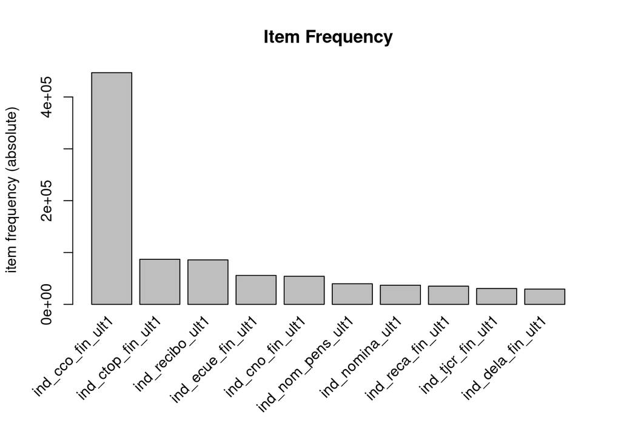

```r
mb_data_transactions <- read.transactions("market_basket_data.txt", sep=" ")

itemFrequencyPlot(mb_data_transactions, topN=10, type="absolute", main="Item Frequency")
```

```r
frequentProducts <- eclat (mb_data_transactions, parameter = list(supp = 0.05, maxlen = 15))
```

```
Eclat

parameter specification:
 tidLists support minlen maxlen            target  ext
    FALSE    0.05      1     15 frequent itemsets TRUE

algorithmic control:
 sparse sort verbose
      7   -2    TRUE

Absolute minimum support count: 27673

create itemset ...
set transactions ...[24 item(s), 553462 transaction(s)] done [0.05s].
sorting and recoding items ... [11 item(s)] done [0.01s].
creating bit matrix ... [11 row(s), 553462 column(s)] done [0.02s].
writing  ... [23 set(s)] done [0.00s].
Creating S4 object  ... done [0.00s].
```

```r
rules <- apriori (mb_data_transactions, parameter = list(supp = 0.05, conf = 0.8))
```

```
Apriori

Parameter specification:
 confidence minval smax arem  aval originalSupport maxtime support minlen
        0.8    0.1    1 none FALSE            TRUE       5    0.05      1
 maxlen target  ext
     10  rules TRUE

Algorithmic control:
 filter tree heap memopt load sort verbose
    0.1 TRUE TRUE  FALSE TRUE    2    TRUE

Absolute minimum support count: 27673

set item appearances ...[0 item(s)] done [0.00s].
set transactions ...[24 item(s), 553462 transaction(s)] done [0.05s].
sorting and recoding items ... [11 item(s)] done [0.01s].
creating transaction tree ... done [0.11s].
checking subsets of size 1 2 3 done [0.00s].
writing ... [11 rule(s)] done [0.00s].
creating S4 object  ... done [0.02s].
```

```r
rules_conf <- sort (rules, by="confidence", decreasing=TRUE)
rules_lift <- sort(rules, by="lift", decreasing=TRUE)

#Remove Redundant Rules
subsetRules <- which(colSums(is.subset(rules, rules)) > 1) # get subset rules in vector
rules <- rules[-subsetRules] # remove subset rules
```

Frequent Items -

```r
 kable(inspect(frequentProducts), "html")
```

```
     items                                                support
[1]  {ind_nom_pens_ult1,ind_nomina_ult1,ind_recibo_ult1}  0.05238661
[2]  {ind_cno_fin_ult1,ind_nom_pens_ult1,ind_nomina_ult1} 0.06306124
[3]  {ind_nomina_ult1,ind_recibo_ult1}                    0.05238661
[4]  {ind_cno_fin_ult1,ind_nomina_ult1}                   0.06306124
[5]  {ind_nom_pens_ult1,ind_nomina_ult1}                  0.06667847
[6]  {ind_cco_fin_ult1,ind_ecue_fin_ult1}                 0.05372727
[7]  {ind_cno_fin_ult1,ind_nom_pens_ult1,ind_recibo_ult1} 0.05355020
[8]  {ind_nom_pens_ult1,ind_recibo_ult1}                  0.05625680
[9]  {ind_cno_fin_ult1,ind_nom_pens_ult1}                 0.06784206
[10] {ind_cco_fin_ult1,ind_ctop_fin_ult1}                 0.10403966
[11] {ind_cno_fin_ult1,ind_recibo_ult1}                   0.07118104
[12] {ind_cco_fin_ult1,ind_recibo_ult1}                   0.08853363
[13] {ind_cco_fin_ult1}                                   0.80752789
[14] {ind_recibo_ult1}                                    0.15498444
```

[output cut: 33 more lines]

|  | items | support | transIdenticalToItemsets | count |
| --- | --- | --- | --- | --- |
| [1] | {ind_nom_pens_ult1,ind_nomina_ult1,ind_recibo_ult1} | 0.0523866 | 28994 | 28994 |
| [2] | {ind_cno_fin_ult1,ind_nom_pens_ult1,ind_nomina_ult1} | 0.0630612 | 34902 | 34902 |
| [3] | {ind_nomina_ult1,ind_recibo_ult1} | 0.0523866 | 28994 | 28994 |
| [4] | {ind_cno_fin_ult1,ind_nomina_ult1} | 0.0630612 | 34902 | 34902 |
| [5] | {ind_nom_pens_ult1,ind_nomina_ult1} | 0.0666785 | 36904 | 36904 |
| [6] | {ind_cco_fin_ult1,ind_ecue_fin_ult1} | 0.0537273 | 29736 | 29736 |
| [7] | {ind_cno_fin_ult1,ind_nom_pens_ult1,ind_recibo_ult1} | 0.0535502 | 29638 | 29638 |
| [8] | {ind_nom_pens_ult1,ind_recibo_ult1} | 0.0562568 | 31136 | 31136 |
| [9] | {ind_cno_fin_ult1,ind_nom_pens_ult1} | 0.0678421 | 37548 | 37548 |
| [10] | {ind_cco_fin_ult1,ind_ctop_fin_ult1} | 0.1040397 | 57582 | 57582 |
| [11] | {ind_cno_fin_ult1,ind_recibo_ult1} | 0.0711810 | 39396 | 39396 |
| [12] | {ind_cco_fin_ult1,ind_recibo_ult1} | 0.0885336 | 49000 | 49000 |
| [13] | {ind_cco_fin_ult1} | 0.8075279 | 446936 | 446936 |
| [14] | {ind_recibo_ult1} | 0.1549844 | 85778 | 85778 |
| [15] | {ind_cno_fin_ult1} | 0.0979435 | 54208 | 54208 |
| [16] | {ind_ctop_fin_ult1} | 0.1570840 | 86940 | 86940 |
| [17] | {ind_nom_pens_ult1} | 0.0717628 | 39718 | 39718 |
| [18] | {ind_ecue_fin_ult1} | 0.1008777 | 55832 | 55832 |
| [19] | {ind_nomina_ult1} | 0.0666785 | 36904 | 36904 |
| [20] | {ind_tjcr_fin_ult1} | 0.0552956 | 30604 | 30604 |
| [21] | {ind_reca_fin_ult1} | 0.0633901 | 35084 | 35084 |
| [22] | {ind_dela_fin_ult1} | 0.0532720 | 29484 | 29484 |
| [23] | {ind_ctpp_fin_ult1} | 0.0506159 | 28014 | 28014 |

```r
frequentProducts
```

```
set of 23 itemsets
```

```r
#FI_df <- data.frame(as.matrix(frequentProducts))
#save_kable(FI_df, "test.csv")

#write.csv(FI_df,file="fi.csv",row.names = FALSE)
```

Association Rules sorted by Confidence

```r
kable(inspect(rules_conf))
```

```
     lhs                    rhs                    support confidence   coverage      lift  count
[1]  {ind_nomina_ult1}   => {ind_nom_pens_ult1} 0.06667847  1.0000000 0.06667847 13.934790  36904
[2]  {ind_cno_fin_ult1,
      ind_nomina_ult1}   => {ind_nom_pens_ult1} 0.06306124  1.0000000 0.06306124 13.934790  34902
[3]  {ind_nomina_ult1,
      ind_recibo_ult1}   => {ind_nom_pens_ult1} 0.05238661  1.0000000 0.05238661 13.934790  28994
[4]  {ind_nom_pens_ult1,
      ind_recibo_ult1}   => {ind_cno_fin_ult1}  0.05355020  0.9518885 0.05625680  9.718752  29638
[5]  {ind_nomina_ult1}   => {ind_cno_fin_ult1}  0.06306124  0.9457511 0.06667847  9.656090  34902
[6]  {ind_nom_pens_ult1,
      ind_nomina_ult1}   => {ind_cno_fin_ult1}  0.06306124  0.9457511 0.06667847  9.656090  34902
[7]  {ind_nom_pens_ult1} => {ind_cno_fin_ult1}  0.06784206  0.9453648 0.07176283  9.652146  37548
[8]  {ind_nom_pens_ult1,
      ind_recibo_ult1}   => {ind_nomina_ult1}   0.05238661  0.9312050 0.05625680 13.965603  28994
[9]  {ind_cno_fin_ult1,
      ind_nom_pens_ult1} => {ind_nomina_ult1}   0.06306124  0.9295302 0.06784206 13.940485  34902
[10] {ind_nom_pens_ult1} => {ind_nomina_ult1}   0.06667847  0.9291505 0.07176283 13.934790  36904
[11] {}                  => {ind_cco_fin_ult1}  0.80752789  0.8075279 1.00000000  1.000000 446936
```

[output not shown]

Association Rules sorted by Lift

```r
kable(inspect(rules_lift))
```

```
     lhs                    rhs                    support confidence   coverage      lift  count
[1]  {ind_nom_pens_ult1,
      ind_recibo_ult1}   => {ind_nomina_ult1}   0.05238661  0.9312050 0.05625680 13.965603  28994
[2]  {ind_cno_fin_ult1,
      ind_nom_pens_ult1} => {ind_nomina_ult1}   0.06306124  0.9295302 0.06784206 13.940485  34902
[3]  {ind_nomina_ult1}   => {ind_nom_pens_ult1} 0.06667847  1.0000000 0.06667847 13.934790  36904
[4]  {ind_cno_fin_ult1,
      ind_nomina_ult1}   => {ind_nom_pens_ult1} 0.06306124  1.0000000 0.06306124 13.934790  34902
[5]  {ind_nomina_ult1,
      ind_recibo_ult1}   => {ind_nom_pens_ult1} 0.05238661  1.0000000 0.05238661 13.934790  28994
[6]  {ind_nom_pens_ult1} => {ind_nomina_ult1}   0.06667847  0.9291505 0.07176283 13.934790  36904
[7]  {ind_nom_pens_ult1,
      ind_recibo_ult1}   => {ind_cno_fin_ult1}  0.05355020  0.9518885 0.05625680  9.718752  29638
[8]  {ind_nomina_ult1}   => {ind_cno_fin_ult1}  0.06306124  0.9457511 0.06667847  9.656090  34902
[9]  {ind_nom_pens_ult1,
      ind_nomina_ult1}   => {ind_cno_fin_ult1}  0.06306124  0.9457511 0.06667847  9.656090  34902
[10] {ind_nom_pens_ult1} => {ind_cno_fin_ult1}  0.06784206  0.9453648 0.07176283  9.652146  37548
[11] {}                  => {ind_cco_fin_ult1}  0.80752789  0.8075279 1.00000000  1.000000 446936
```

[output not shown]

We can infer that, the product combinations of {Payroll, Pensions}, {Payroll Account + Payroll , Pensions} and {Payroll + Direct Debit , Pensions} have always been bought together. From the association rules, it is clear that the Payroll, Payroll Account, Pensions, Direct Debit and Current accounts products are most likely to be purchased together.

Modeling and Performance Evaluation

```r
labels = colnames(data)[17:40]
data <- as.data.frame(data)
data[,17:40] <- apply(as.matrix(data[,17:40]),2, function(x) as.logical(x));

# #data <- subset(data, select=(-c(ind_aval_fin_ult1)))
# labels <- labels[!c("ind_aval_fin_ult1") %in% labels]
# data<- data %>% drop_na

data$antiguedad <- as.integer(data$antiguedad)
data$month_alta <- factor(data$month_alta, ordered = FALSE)

model_data <- data[,c(-1,-3,-6,-12,-13)]

model_data$ind_empleado <- as.factor(model_data$ind_empleado)
model_data$indresi <- as.factor(model_data$indresi)
model_data$provinces <- as.factor(model_data$provinces)
model_data$channel <- as.factor(model_data$channel)
model_data$countries <- as.factor(model_data$countries)

mysample <- sample(1:nrow(model_data),0.7*nrow(model_data))
train_data <- model_data[mysample,]
test_data <- model_data[-mysample,]

train_data_rfsrc <- train_data
train_data_rfsrc$month_alta <- factor(train_data_rfsrc$month_alta, ordered = FALSE)
train_data_rfsrc_sample <- sample(1:nrow(train_data_rfsrc),0.3*nrow(train_data_rfsrc))
train_data_rfsrc <- train_data_rfsrc[train_data_rfsrc_sample,]
test_data_rfsrc <- train_data_rfsrc[-train_data_rfsrc_sample,]
test_data_rfsrc <- test_data_rfsrc[sample(1:nrow(test_data_rfsrc),0.5*nrow(test_data_rfsrc)),]
# train_data_rfsrc$antiguedad <- as.integer(train_data_rfsrc$antiguedad)
# train_data$antiguedad <- as.integer(train_data$antiguedad)
products_task_train_rfsrc = makeMultilabelTask(id = "products_rfsrc", data = train_data_rfsrc, target = labels)
train_data <- na.omit(train_data)
products_task_train = makeMultilabelTask(id = "products", data = train_data, target = labels)
```

Binary Relevance Problem Transformation Method

```r
library(mlr)
#Constructing the Learner
learn_br_prob = makeLearner("classif.rpart", predict.type = "prob")
learn_br_prob = makeMultilabelBinaryRelevanceWrapper(learn_br_prob)

#Model Training
br_model = mlr::train(learn_br_prob, products_task_train)

#Model Prediction
br_model_pred = predict(br_model, task = products_task_train)

#removed na because below predict fn was giving error
test_data <- test_data %>% drop_na()

br_model_pred_test = predict(br_model, newdata=test_data)

#Model Performance
br_model_perf <- performance(br_model_pred, measures = list(multilabel.subset01, multilabel.hamloss, multilabel.acc, multilabel.f1, timepredict))
br_model_perf_test <- performance(br_model_pred_test, measures = list(multilabel.subset01, multilabel.hamloss, multilabel.acc, multilabel.f1, timepredict))

getMultilabelBinaryPerformances(br_model_pred_test, measures = list(mlr::acc, mlr::fpr, mlr::tpr, mlr::auc))
```

```
                  acc.test.mean fpr.test.mean tpr.test.mean auc.test.mean
ind_ahor_fin_ult1     1.0000000   0.000000000           NaN            NA
ind_aval_fin_ult1     0.9998652   0.000000000    0.00000000     0.5000000
ind_cco_fin_ult1      0.7423160   0.472093492    0.85009622     0.7296649
ind_cder_fin_ult1     0.9996630   0.000000000    0.00000000     0.5000000
ind_cno_fin_ult1      0.9214748   0.000000000    0.00000000     0.5000000
ind_ctju_fin_ult1     0.9997978   0.000134971    0.94444444     0.9721341
ind_ctma_fin_ult1     0.9894850   0.000000000    0.00000000     0.5000000
ind_ctop_fin_ult1     0.8831895   0.040567794    0.37757202     0.8801615
ind_ctpp_fin_ult1     0.9590860   0.000000000    0.00000000     0.5000000
ind_deco_fin_ult1     0.9979779   0.000000000    0.00000000     0.5000000
ind_deme_fin_ult1     0.9983823   0.000000000    0.00000000     0.5000000
ind_dela_fin_ult1     0.9574009   0.011609907    0.25160256     0.7239802
ind_ecue_fin_ult1     0.9193179   0.004477393    0.06270627     0.6047738
ind_fond_fin_ult1     0.9807900   0.000000000    0.00000000     0.5000000
ind_hip_fin_ult1      0.9951469   0.000000000    0.00000000     0.5000000
ind_plan_fin_ult1     0.9909679   0.000000000    0.00000000     0.5000000
ind_pres_fin_ult1     0.9971016   0.000000000    0.00000000     0.5000000
ind_reca_fin_ult1     0.9473578   0.000000000    0.00000000     0.5000000
ind_tjcr_fin_ult1     0.9566595   0.000000000    0.00000000     0.5000000
ind_valo_fin_ult1     0.9743866   0.000000000    0.00000000     0.5000000
ind_viv_fin_ult1      0.9972365   0.000000000    0.00000000     0.5000000
ind_nomina_ult1       0.9474252   0.000000000    0.00000000     0.5000000
ind_nom_pens_ult1     0.9433136   0.000000000    0.00000000     0.5000000
ind_recibo_ult1       0.8725398   0.000000000    0.00000000     0.5000000
```

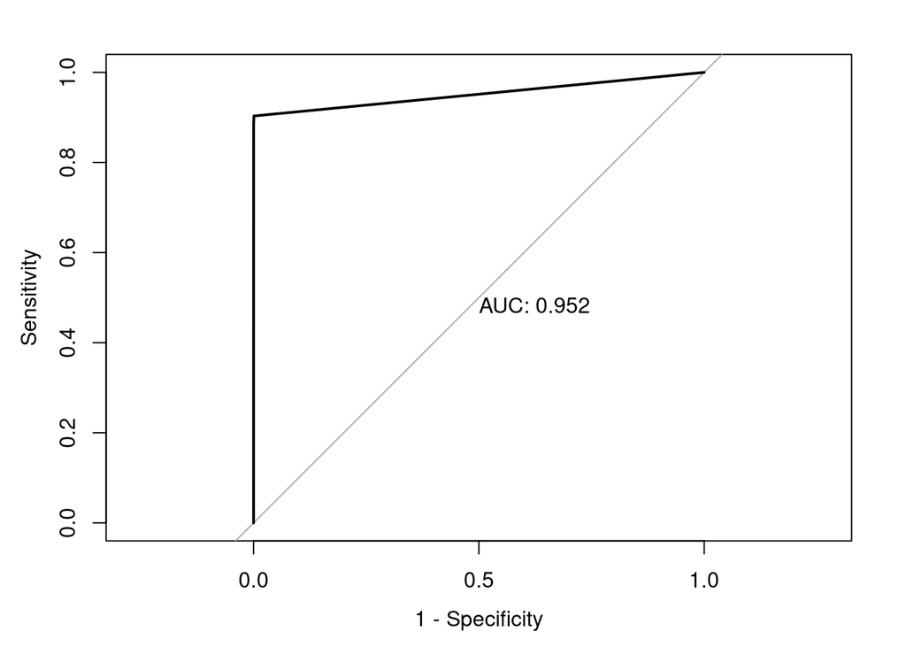

```r
library(pROC)
#roc for ind_ctju_fin_ult1
pp <- br_model_pred$data$truth.ind_ctju_fin_ult1
qq <- br_model_pred$data$prob.ind_ctju_fin_ult1
roc1 <- roc(pp, qq, plot = TRUE, print.auc = TRUE,legacy.axes = TRUE, legend=TRUE)
```

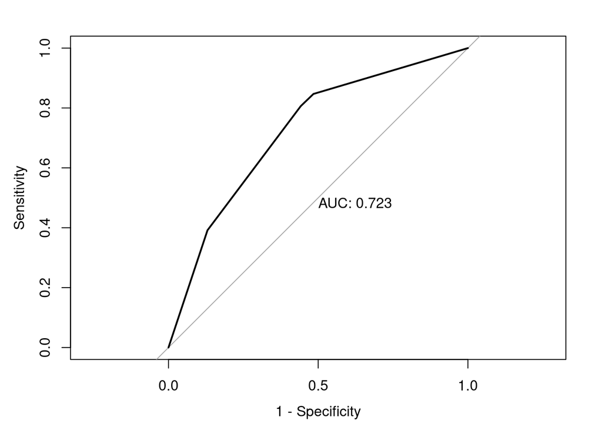

```r
#roc for ind_cco_fin_ult1
pp <- br_model_pred$data$truth.ind_cco_fin_ult1
qq <- br_model_pred$data$prob.ind_cco_fin_ult1
roc2<- roc(pp, qq, plot = TRUE, print.auc = TRUE,legacy.axes = TRUE, legend = TRUE)
```

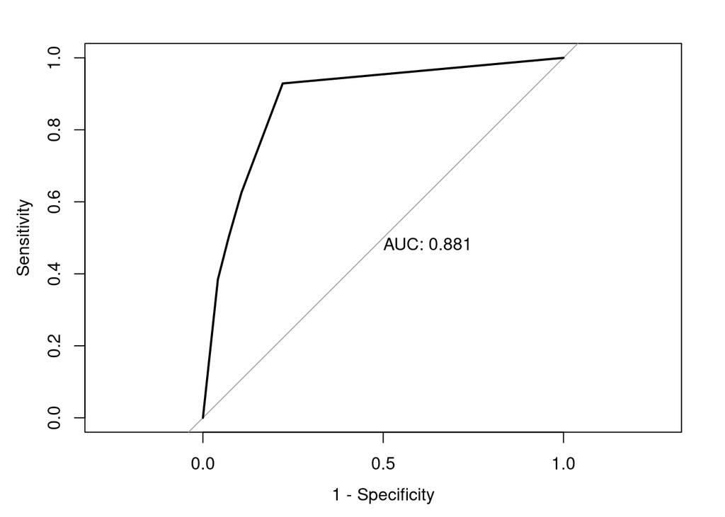

```r
#roc for truth.ind_ctop_fin_ult1
pp <- br_model_pred$data$truth.ind_ctop_fin_ult1
qq <- br_model_pred$data$prob.ind_ctop_fin_ult1
roc3 <- roc(pp, qq, plot = TRUE, print.auc = TRUE,legacy.axes = TRUE, legend = TRUE)
```

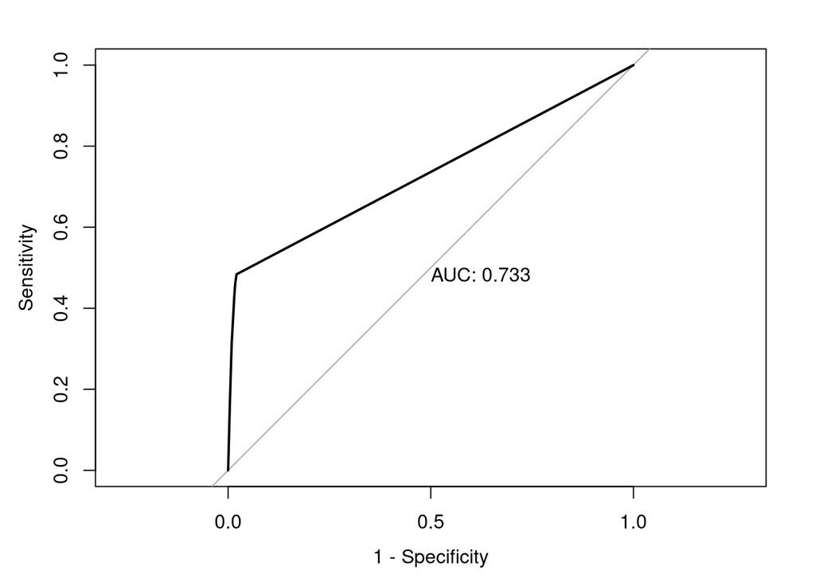

```r
#roc for ind_dela_fin_ult1
pp <- br_model_pred$data$truth.ind_dela_fin_ult1
qq <- br_model_pred$data$prob.ind_dela_fin_ult1
roc4 <- roc(pp, qq, plot = TRUE, print.auc = TRUE,legacy.axes = TRUE, legend = TRUE)
```

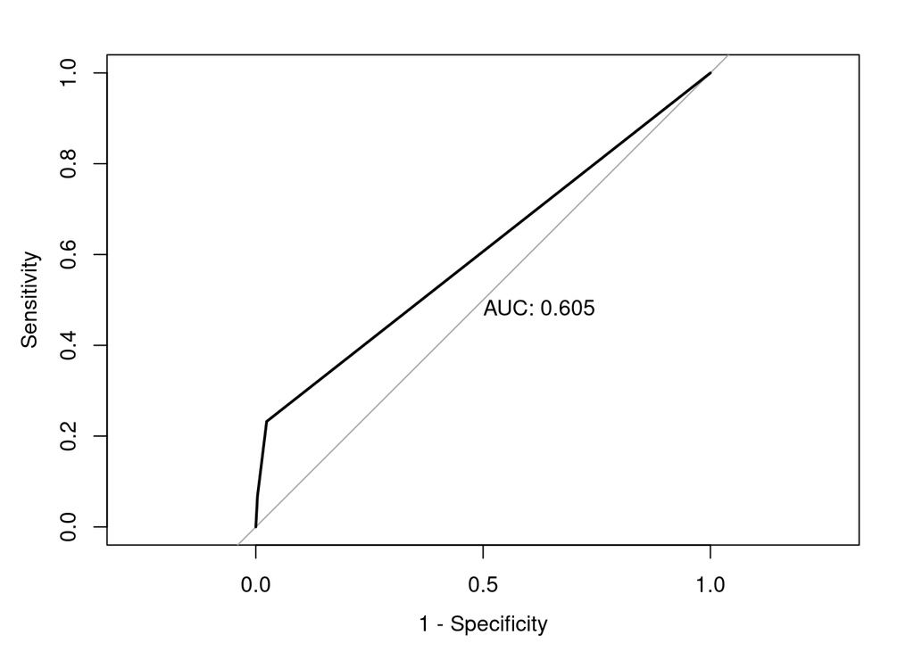

```r
#roc for ind_ecue_fin_ult1
pp <- br_model_pred$data$truth.ind_ecue_fin_ult1
qq <- br_model_pred$data$prob.ind_ecue_fin_ult1
roc5 <- roc(pp, qq, plot = TRUE, print.auc = TRUE,legacy.axes = TRUE, legend = TRUE)
```

[figure not shown]

```r
plot(roc1, col = 1, lty = 2, main = "ROC Cure for Binary Relevance Reression Tree Model ", legacy.axes = TRUE)
plot(roc2, col = 4, lty = 3, add = TRUE, legacy.axes = TRUE)
plot(roc3, col = 7, lty = 4, add = TRUE, legacy.axes = TRUE)
plot(roc4, col = 11, lty = 5, add = TRUE, legacy.axes = TRUE)

plot(roc5, col = 15, lty = 6, add = TRUE, legacy.axes = TRUE + xlim(0, 1))

legend("bottomright", legend=c("ind_ctju_fin_ult1", "ind_cco_fin_ult1","truth.ind_ctop_fin_ult1","ind_dela_fin_ult1", "ind_ecue_fin_ult1"), col = c("red","blue","green","orange","pink"), lty=1:2, cex=0.8, text.font=4, bg='lightblue')
```

Logistic Regression:-

```r
library(e1071)

logistic.learner <- makeLearner("classif.logreg",predict.type = "prob")
logistic.learner <- makeMultilabelBinaryRelevanceWrapper(logistic.learner)
#products_task_train$env$data <- products_task_train$env$data %>% drop_na()

#train model
logistic.model <- mlr::train(logistic.learner, products_task_train)

#predict on test data
logistic.model.pred <- predict(logistic.model, newdata=test_data)


logistic.model_perf_test <- performance(logistic.model.pred, measures = list(multilabel.subset01, multilabel.hamloss, multilabel.acc, multilabel.f1, timepredict))

logistic.model_perf_test
```

```
multilabel.subset01  multilabel.hamloss      multilabel.acc       multilabel.f1
         0.48645187          0.04387133          0.59603397          0.62792667
        timepredict
         0.46900000
```

```r
#cross validation (10 fold logistic regression) (cv) accuracy
#cv.logistic <- crossval(learner = logistic.learner,task = products_task_train,iters = 10, show.info = T)

getMultilabelBinaryPerformances(logistic.model.pred, measures = list(mlr::acc, mlr::fpr, mlr::tpr, mlr::auc))
```

```
                  acc.test.mean fpr.test.mean tpr.test.mean auc.test.mean
ind_ahor_fin_ult1     1.0000000  0.0000000000           NaN            NA
ind_aval_fin_ult1     0.9997304  0.0001348254   0.000000000     0.4963260
ind_cco_fin_ult1      0.7419790  0.4906306669   0.858908133     0.7582251
ind_cder_fin_ult1     0.9996630  0.0000000000   0.000000000     0.8269570
ind_cno_fin_ult1      0.9216096  0.0001462951   0.003433476     0.8706255
ind_ctju_fin_ult1     0.9995282  0.0004723984   1.000000000     0.9996738
ind_ctma_fin_ult1     0.9894850  0.0000000000   0.000000000     0.8434596
ind_ctop_fin_ult1     0.8591264  0.0370772572   0.170781893     0.8919025
ind_ctpp_fin_ult1     0.9590860  0.0000000000   0.000000000     0.8126731
ind_deco_fin_ult1     0.9979779  0.0000000000   0.000000000     0.8875028
ind_deme_fin_ult1     0.9983823  0.0000000000   0.000000000     0.8763193
ind_dela_fin_ult1     0.9600297  0.0111877287   0.304487179     0.9286743
ind_ecue_fin_ult1     0.9183068  0.0093217851   0.104785479     0.8656289
ind_fond_fin_ult1     0.9804530  0.0003436190   0.000000000     0.9277766
ind_hip_fin_ult1      0.9951469  0.0000000000   0.000000000     0.9335047
ind_plan_fin_ult1     0.9908331  0.0001360359   0.000000000     0.9181627
ind_pres_fin_ult1     0.9971016  0.0000000000   0.000000000     0.9057859
ind_reca_fin_ult1     0.9474252  0.0000000000   0.001280410     0.8592822
ind_tjcr_fin_ult1     0.9563899  0.0002818291   0.000000000     0.8971810
ind_valo_fin_ult1     0.9741170  0.0002767017   0.000000000     0.9150981
ind_viv_fin_ult1      0.9972365  0.0000000000   0.000000000     0.8956256
ind_nomina_ult1       0.9474926  0.0000000000   0.001282051     0.8768351
ind_nom_pens_ult1     0.9433136  0.0000000000   0.000000000     0.8704715
ind_recibo_ult1       0.8726746  0.0030127462   0.021681650     0.8807436
```

Random Forests Algorithm Adapatation Method:-

```r
#Constructing the Learner
lrn.rfsrc = makeLearner("multilabel.randomForestSRC")

#Model Training
rfsrc_model = train(lrn.rfsrc,products_task_train_rfsrc)
rfsrc_model
```

```
Model for learner.id=multilabel.randomForestSRC; learner.class=multilabel.randomForestSRC
Trained on: task.id = products_rfsrc; obs = 10500; features = 16
Hyperparameters: na.action=na.impute
```

```r
#Model Prediction
rfsrc_model_pred = predict(rfsrc_model, task=products_task_train_rfsrc)
# removed na as predict fn below was giving error
test_data_rfsrc <- test_data_rfsrc %>% drop_na()

rfsrc_model_pred
```

```
Prediction: 10500 observations
predict.type: response
threshold:
time: 8.57
      id truth.ind_ahor_fin_ult1 truth.ind_aval_fin_ult1 truth.ind_cco_fin_ult1
2508   1                   FALSE                   FALSE                   TRUE
10974  2                   FALSE                   FALSE                   TRUE
21703  3                   FALSE                   FALSE                  FALSE
34121  4                   FALSE                   FALSE                   TRUE
21958  5                   FALSE                   FALSE                  FALSE
17664  6                   FALSE                   FALSE                   TRUE
      truth.ind_cder_fin_ult1 truth.ind_cno_fin_ult1 truth.ind_ctju_fin_ult1
2508                    FALSE                  FALSE                   FALSE
10974                   FALSE                  FALSE                   FALSE
21703                   FALSE                  FALSE                   FALSE
```

[output cut: 130 more lines]

```r
rfsrc_model_pred_test = predict(rfsrc_model, newdata=test_data_rfsrc)

#Model Performance
rfsrc_model_perf <- performance(rfsrc_model_pred, measures = list(multilabel.subset01, multilabel.hamloss, multilabel.acc, multilabel.f1, timepredict))
rfsrc_model_perf_test <- performance(rfsrc_model_pred_test, measures = list(multilabel.subset01, multilabel.hamloss, multilabel.acc, multilabel.f1, timepredict))

rfsrc_model_perf
```

```
multilabel.subset01  multilabel.hamloss      multilabel.acc       multilabel.f1
       0.0022857143        0.0001031746        0.9977857143        0.9977959184
        timepredict
       8.5690000000
```

```r
rfsrc_model_perf_test
```

```
multilabel.subset01  multilabel.hamloss      multilabel.acc       multilabel.f1
       0.0005523336        0.0000230139        0.9994476664        0.9994476664
        timepredict
       4.3460000000
```

```r
#cross validation (10 fold random forest) (cv) accuracy
lrn.rfsrc = makeLearner("multilabel.randomForestSRC")
cv.logistic <- crossval(learner = lrn.rfsrc,task = products_task_train_rfsrc,iters = 10,show.info = F)

# #Feature importance
# im_feat <- generateFilterValuesData(products_task_train_rfsrc, method = c("information.gain","chi.squared"))
# plotFilterValues(im_feat,n.show = 20)
```

Neural Networks Algorithm Adaptation Method

```r
model_data_nn <- model_data
model_data_nn[,12:35] <- apply(model_data[,12:35], 2, function(x) as.numeric(x));
model_data_nn$segmento <- as.character(model_data_nn$segmento)
model_data_nn[model_data_nn$segmento == "02 - PARTICULARES", "segmento"] <- "PARTICULARES"
model_data_nn[model_data_nn$segmento == "03 - UNIVERSITARIO", "segmento"] <- "UNIVERSITARIO"
model_data_nn[model_data_nn$segmento == "01 - TOP", "segmento"] <- "TOP"
col_names <- names(model_data_nn)
formula <- as.formula(paste(paste(labels, collapse="+"),"~", paste(col_names[!col_names %in% labels], collapse = " + ")))

m <- model.matrix(~ind_ahor_fin_ult1 + ind_aval_fin_ult1 + ind_cco_fin_ult1 + ind_cder_fin_ult1 +
                      ind_cno_fin_ult1 + ind_ctju_fin_ult1 + ind_ctma_fin_ult1 +
                      ind_ctop_fin_ult1 + ind_ctpp_fin_ult1 + ind_deco_fin_ult1 +
                      ind_deme_fin_ult1 + ind_dela_fin_ult1 + ind_ecue_fin_ult1 +
                      ind_fond_fin_ult1 + ind_hip_fin_ult1 + ind_plan_fin_ult1 +
                      ind_pres_fin_ult1 + ind_reca_fin_ult1 + ind_tjcr_fin_ult1 +
                      ind_valo_fin_ult1 + ind_viv_fin_ult1 + ind_nomina_ult1 +
                      ind_nom_pens_ult1 + ind_recibo_ult1 + ind_empleado + sexo +
                      age + ind_nuevo + antiguedad + indrel + tiprel_1mes + indresi +
                      ind_actividad_cliente + renta + segmento + provinces + countries +
                      channel, data=model_data_nn)
m <- as.data.frame(m)
m <- m[,c(-1)]
col_names <- names(m)
formula <- as.formula(paste(paste(labels, collapse="+"),"~", paste(col_names[!col_names %in% labels], collapse = " + ")))

train_data_nn <- m[mysample,]
test_data_nn <- m[-mysample,]

train_data_nn[is.na(train_data_nn)] <- 0

neural_net <- neuralnet(formula,
                data = train_data_nn,
                act.fct = "logistic",
                linear.output = FALSE,
                lifesign = "minimal")

 plot(neural_net, width = 1200, height = 500)



#Compute Predictions
neural_net_predict <- compute(neural_net, train_data_nn[, c(25:50)])
neural_net_predict_test <- compute(neural_net, test_data_nn[,25:50])


#Extract Results
neural_net_predictions <- neural_net_predict$net.result
neural_net_predictions <- apply(neural_net_predictions,2,function(x) round(x))
head(neural_net_predictions)
```

[output not shown]

```
      [,1] [,2] [,3] [,4] [,5] [,6] [,7] [,8] [,9] [,10] [,11] [,12] [,13]
34198    0    0    1    0    0    0    0    0    0     0     0     0     0
8503     0    0    1    0    0    0    0    0    0     0     0     0     0
48912    0    0    1    0    0    0    0    0    0     0     0     0     0
6870     0    0    1    0    0    0    0    0    0     0     0     0     0
44251    0    0    1    0    0    0    0    0    0     0     0     0     0
36224    0    0    1    0    0    0    0    0    0     0     0     0     0
      [,14] [,15] [,16] [,17] [,18] [,19] [,20] [,21] [,22] [,23] [,24]
34198     0     0     0     0     0     0     0     0     0     0     0
8503      0     0     0     0     0     0     0     0     0     0     0
48912     0     0     0     0     0     0     0     0     0     0     0
6870      0     0     0     0     0     0     0     0     0     0     0
44251     0     0     0     0     0     0     0     0     0     0     0
36224     0     0     0     0     0     0     0     0     0     0     0
```

```r
neural_net_predictions_test <- neural_net_predict_test$net.result
neural_net_predictions_test <- apply(neural_net_predictions_test,2,function(x) round(x))

# Accuracy (training set)
original_values <- train_data_nn[, 1:24]
row_match <- as.array(seq(from=0,to=0,length.out=dim(train_data_nn)[1]))
row_mismatch <- as.array(seq(from=0,to=0,length.out=dim(train_data_nn)[1]))

for(i in 1:dim(neural_net_predictions)[1])
  {for(j in 1:dim(neural_net_predictions)[2])
  {
    if(neural_net_predictions[i,j]==original_values[i,j]){ row_match[i]=row_match[i]+1}
    else {row_mismatch[i]=row_mismatch[i]+1}
  }
}
nnet_perf_train <- mean((row_match-row_mismatch)/24)

# Accuracy (test set)
original_values <- test_data_nn[, 1:24]
row_match <- as.array(seq(from=0,to=0,length.out=dim(test_data_nn)[1]))
row_mismatch <- as.array(seq(from=0,to=0,length.out=dim(test_data_nn)[1]))

for(i in 1:dim(neural_net_predictions_test)[1])
  {for(j in 1:dim(neural_net_predictions_test)[2])
  {
    if(neural_net_predictions_test[i,j]==original_values[i,j]){ row_match[i]=row_match[i]+1}
    else {row_mismatch[i]=row_mismatch[i]+1}
  }
}

nnet_perf_test <- mean((row_match-row_mismatch)/24)
nnet_perf_test
```

```
[1] 0.9046167
```

```r
#Binary Relevance Performance Regression Tree
#kable(br_model_perf)
kable(br_model_perf_test)
```

|  | x |
| --- | --- |
| multilabel.subset01 | 0.4716231 |
| multilabel.hamloss | 0.0428799 |
| multilabel.acc | 0.6068347 |
| multilabel.f1 | 0.6368671 |
| timepredict | 0.5270000 |

```r
#Binary Relevance Logistic Tree :

kable(logistic.model_perf_test)
```

|  | x |
| --- | --- |
| multilabel.subset01 | 0.4864519 |
| multilabel.hamloss | 0.0438713 |
| multilabel.acc | 0.5960340 |
| multilabel.f1 | 0.6279267 |
| timepredict | 0.4690000 |

```r
#Random Forests Performance
#kable(rfsrc_model_perf)
kable(rfsrc_model_perf_test)
```

|  | x |
| --- | --- |
| multilabel.subset01 | 0.0005523 |
| multilabel.hamloss | 0.0000230 |
| multilabel.acc | 0.9994477 |
| multilabel.f1 | 0.9994477 |
| timepredict | 4.3460000 |

```r
#Neural Net Accuracy
#kable(nnet_perf_train)
kable(nnet_perf_test)
```

| x |
| --- |
| 0.9046167 |

```r
#Cross Validation Training errors
# kable(cv_10_fold_br)
# kable(resample_br)
#
# kable(cv_10_fold_rfsrc)
# kable(resample_rfsrc)
#
# kable(cv_10_fold_nnet)
```

Conclusion:-